# Model Revision

Jen Baron

May 22, 2020

This is the same code as the original analysis, but I’m now modelling the raw amount of buckthorn (instead of the relative abundance)

```r
library(plyr)
library(tidyverse)
library(nlme)
library(lme4)
library(glmmTMB)
library(RColorBrewer)
library(ggrepel)
library(gridExtra)
library(DHARMa)
library(emmeans)
library(dplyr)
```

# 1 Create Scores

## 1.1 Read in & Join EI Data

```r
gap.area <- read.csv("data/gap_area.csv") %>% select(-X, -Gap)
names(gap.area)[4] <-"Gap Area"
str(gap.area)
```

```
## 'data.frame':    48 obs. of  4 variables:
##  $ Location: chr  "Code Farm" "Code Farm" "Code Farm" "Code Farm" ...
##  $ Category: chr  "EAB Gap" "EAB Gap" "EAB Gap" "EAB Gap" ...
##  $ ID      : int  1 2 3 4 1 2 3 4 1 2 ...
##  $ Gap Area: num  90.4 139.6 114.1 166.4 59.8 ...
```

```r
dist.edge <- read.csv("data/dist_edge.csv")
names(dist.edge)[4]<-"Edge Distance"
str(dist.edge)
```

```
## 'data.frame':    72 obs. of  4 variables:
##  $ Location     : chr  "Code Farm" "Code Farm" "Code Farm" "Code Farm" ...
##  $ Category     : chr  "EAB Gap" "Other Gap" "Non-Gap" "EAB Gap" ...
##  $ ID           : int  1 1 1 2 2 2 3 3 3 4 ...
##  $ Edge Distance: num  5.59 91.01 85.46 61.89 54.86 ...
```

```r
frag.size <-read.csv("data/frag_size.csv")
names(frag.size)[2] <- "Fragment Size"
str(frag.size)
```

```
## 'data.frame':    6 obs. of  2 variables:
##  $ Location     : chr  "Westminster Ponds" "Meadowlily Woods" "Medway Valley" "Five Points Forest" ...
##  $ Fragment Size: int  199 324 230 174 11 37
```

```r
shade.tol <- read.csv("data/shade_tol.csv") %>% select(-X, -Gap, -tot.BA)
names(shade.tol)[4] <- "Shade Tolerance"
str(shade.tol)
```

```
## 'data.frame':    24 obs. of  4 variables:
##  $ Location       : chr  "Code Farm" "Code Farm" "Code Farm" "Code Farm" ...
##  $ Category       : chr  "Non-Gap" "Non-Gap" "Non-Gap" "Non-Gap" ...
##  $ ID             : int  1 2 3 4 1 2 3 4 1 2 ...
##  $ Shade Tolerance: num  4.44 4.52 4.18 4.53 3.33 ...
```

```r
tree <- read.csv("data/percent_t.csv") %>% select(-X) #wondering if this should be absolute or relative...
names(tree)[4] <- "Percent Tree" #absolute right now (not relative to shrub cover)
str(tree)
```

```
## 'data.frame':    72 obs. of  4 variables:
##  $ Location    : chr  "Code Farm" "Code Farm" "Code Farm" "Code Farm" ...
##  $ ID          : int  1 1 1 2 2 2 3 3 3 4 ...
##  $ Category    : chr  "EAB Gap" "Non-Gap" "Other Gap" "EAB Gap" ...
##  $ Percent Tree: int  50 70 60 90 50 40 80 110 120 30 ...
```

```r
mgmt <- read.csv("data/management.csv")
str(mgmt)
```

```
## 'data.frame':    6 obs. of  3 variables:
##  $ Location            : chr  "Westminster Ponds" "Meadowlily Woods" "Medway Valley" "Five Points Forest" ...
##  $ Management          : chr  "Public" "Public" "Public" "Private" ...
##  $ Buckthorn_Management: int  1 1 1 1 0 0
```

```r
EI <- full_join(dist.edge, gap.area, by = c("Location", "Category", "ID"))
EI2 <- full_join(EI, frag.size, by = c("Location"))
EI3 <- full_join(EI2, shade.tol, by = c("Location", "Category", "ID"))
EI4 <- full_join(EI3, tree, by = c("Location", "Category", "ID"))
EI5 <- full_join(EI4, mgmt, by = c("Location"))
EI5$Category <- as.factor(EI5$Category)
names(EI5) <- sub(" ", ".", names(EI5)) #Replace spaces with .
str(EI5)
```

```
## 'data.frame':    72 obs. of  10 variables:
##  $ Location            : chr  "Code Farm" "Code Farm" "Code Farm" "Code Farm" ...
##  $ Category            : Factor w/ 3 levels "EAB Gap","Non-Gap",..: 1 3 2 1 2 3 3 1 2 1 ...
##  $ ID                  : int  1 1 1 2 2 2 3 3 3 4 ...
##  $ Edge.Distance       : num  5.59 91.01 85.46 61.89 54.86 ...
##  $ Gap.Area            : num  90.4 59.8 NA 139.6 NA ...
##  $ Fragment.Size       : int  37 37 37 37 37 37 37 37 37 37 ...
##  $ Shade.Tolerance     : num  NA NA 4.44 NA 4.52 ...
##  $ Percent.Tree        : int  50 60 70 90 50 40 120 80 110 30 ...
##  $ Management          : chr  "Private" "Private" "Private" "Private" ...
##  $ Buckthorn_Management: int  0 0 0 0 0 0 0 0 0 0 ...
```

## 1.2 Create Matrix for EI Analysis

Variables:

- Edge Distance - plot specific: lower number = lower integrity
- Fragment Size - site specific: lower number = lower integrity
- Shade Tolerance - site specific: lower number = lower integrity?
- Percent Tree - plot specific: lower number = lower integrity?
- Management - site specific: lower number = lower integrity?

```r
shade.tol.site <- EI5 %>% #summarize shade tolerance by site
  filter(Category == "Non-Gap") %>%
  group_by(Location) %>%
  summarize(Shade.Tolerance.Site = mean(Shade.Tolerance))

str(shade.tol.site)
```

```
## tibble [6 × 2] (S3: tbl_df/tbl/data.frame)
##  $ Location            : chr [1:6] "Code Farm" "Field Research Station" "Five Points Forest" "Meadowlily Woods" ...
##  $ Shade.Tolerance.Site: num [1:6] 4.42 3.33 4.18 4.02 4.82 ...
```

```r
EI6 <- full_join(EI5, shade.tol.site, by = c("Location")) %>% select(-Shade.Tolerance)

gap.area.site <- EI5 %>% #summarize gap area
  filter(Category != "Non-Gap") %>%
  group_by(Location) %>%
  summarize(Gap.Area.Site = mean(Gap.Area))

EI7 <- full_join(EI6, gap.area.site, by = c("Location")) %>% select(-Gap.Area)

head(EI7)
```

```
##    Location  Category ID Edge.Distance Fragment.Size Percent.Tree Management
## 1 Code Farm   EAB Gap  1          5.59            37           50    Private
## 2 Code Farm Other Gap  1         91.01            37           60    Private
## 3 Code Farm   Non-Gap  1         85.46            37           70    Private
## 4 Code Farm   EAB Gap  2         61.89            37           90    Private
## 5 Code Farm   Non-Gap  2         54.86            37           50    Private
## 6 Code Farm Other Gap  2        120.79            37           40    Private
##   Buckthorn_Management Shade.Tolerance.Site Gap.Area.Site
## 1                    0             4.418994      136.4042
## 2                    0             4.418994      136.4042
## 3                    0             4.418994      136.4042
## 4                    0             4.418994      136.4042
## 5                    0             4.418994      136.4042
## 6                    0             4.418994      136.4042
```

```r
#write.csv(EI7, file = "EI.csv")
```

## 1.3 Run without and without gap area

```r
EI7 %>% select(Edge.Distance, Fragment.Size, Percent.Tree, Shade.Tolerance.Site) -> EI.data

prcomp(EI.data, scale. = TRUE) -> EI.pca

summary(EI.pca)
```

```
## Importance of components:
##                           PC1    PC2    PC3     PC4
## Standard deviation     1.3486 1.0648 0.8749 0.53106
## Proportion of Variance 0.4547 0.2835 0.1914 0.07051
## Cumulative Proportion  0.4547 0.7381 0.9295 1.00000
```

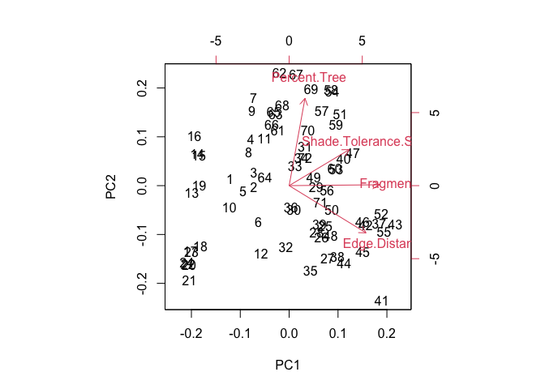

```r
biplot(EI.pca)
```

```r
PC1 <- predict(EI.pca)[,1]
PC2 <- predict(EI.pca)[,2]

EI7 %>% select(Edge.Distance, Fragment.Size, Percent.Tree, Shade.Tolerance.Site, Gap.Area.Site) %>%
  prcomp(scale. = TRUE) -> EI.pca2

summary(EI.pca2)
```

```
## Importance of components:
##                           PC1    PC2    PC3     PC4     PC5
## Standard deviation     1.4839 1.1522 0.9228 0.58280 0.52837
## Proportion of Variance 0.4404 0.2655 0.1703 0.06793 0.05584
## Cumulative Proportion  0.4404 0.7059 0.8762 0.94416 1.00000
```

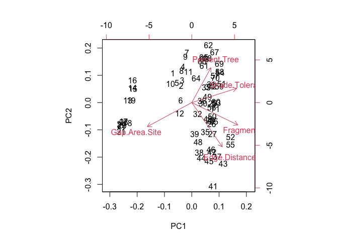

```r
biplot(EI.pca2)
```

```r
PC1b <- predict(EI.pca2)[,1]
PC2b <- predict(EI.pca2)[,2]
```

```r
rescale.U <- rep(EI.pca$sdev, each = length(EI.pca$sdev)) #get lengths

U.scale2 <- EI.pca$rotation * rescale.U #multiply lengths by sqrt SD

round(U.scale2^2,2) #variability in each variable for each PC
```

```
##                       PC1  PC2  PC3  PC4
## Edge.Distance        0.60 0.23 0.07 0.11
## Fragment.Size        0.83 0.00 0.03 0.14
## Percent.Tree         0.03 0.78 0.18 0.02
## Shade.Tolerance.Site 0.37 0.13 0.49 0.01
```

### 1.3.1 QQ plots for PCA

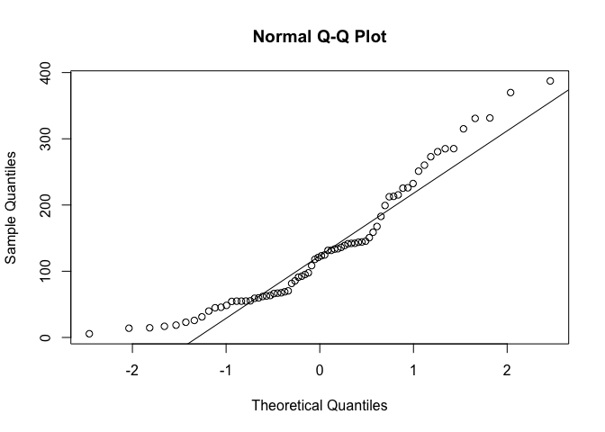

```r
qqnorm(EI.data[,1]);qqline(EI.data[,1])
```

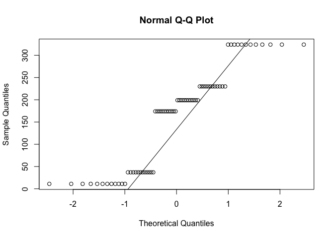

```r
qqnorm(EI.data[,2]);qqline(EI.data[,2])
```

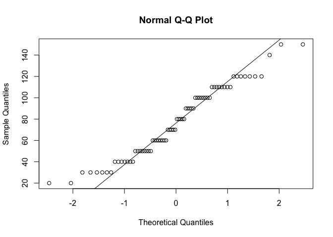

```r
qqnorm(EI.data[,3]);qqline(EI.data[,3])
```

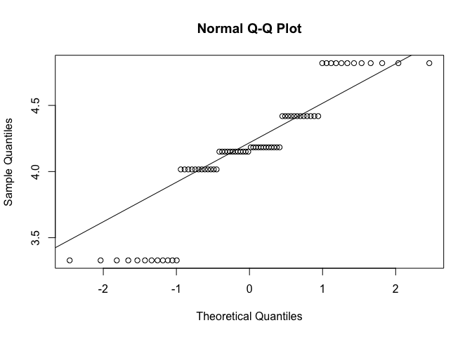

```r
qqnorm(EI.data[,4]);qqline(EI.data[,4])
```

### 1.3.2 PCA BiPlot

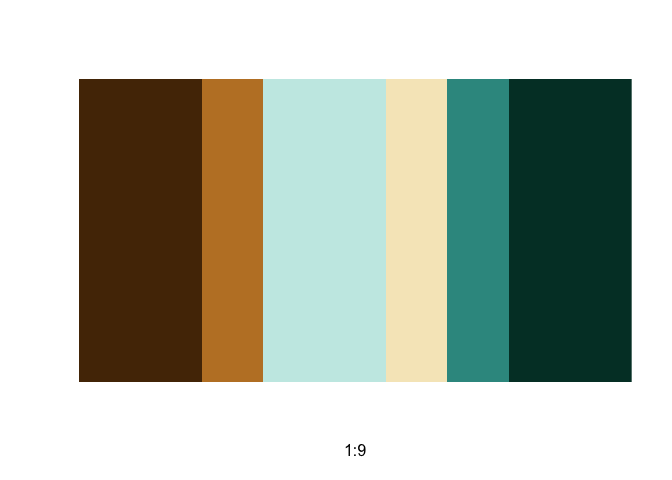

```r
#display.brewer.all(colorblindFriendly = TRUE)
mypalette <-brewer.pal(11,"BrBG")[c(1,3,7,5,9,11)]
#mypalette <- c("","","lightseagreen", "lightskyblue2", "dodgerblue",  "dodgerblue4")
image(1:9,1,as.matrix(1:9),col=mypalette,ylab="",xaxt="n",yaxt="n",bty="n")
```

```r
U <- data.frame(EI.pca$rotation)
colnames(U) <- colnames(EI.pca$rotation)
rownames(U) <- rownames(EI.pca$rotation)
U$descriptors <- rownames(U)
F.1 <- data.frame(EI.pca$x) # The book calls this matrix F but I use F.1 because in R, F is shorthand for FALSE
colnames(F.1) <- colnames(EI.pca$x)
rownames(F.1) <- rownames(EI.pca$x)
str(U)
```

```
## 'data.frame':    4 obs. of  5 variables:
##  $ PC1        : num  0.574 0.674 0.118 0.449
##  $ PC2        : num  -0.44703 0.00827 0.82678 0.34137
##  $ PC3        : num  0.292 0.198 0.486 -0.799
##  $ PC4        : num  -0.621 0.711 -0.257 -0.207
##  $ descriptors: chr  "Edge.Distance" "Fragment.Size" "Percent.Tree" "Shade.Tolerance.Site"
```

```r
levels(U$descriptors) <- c("Distance from Forest Edge", "Forest Fragment Size", "Tree Regeneration", "Successional Stage")
U$descriptors <- as.factor(U$descriptors)
str(U)
```

```
## 'data.frame':    4 obs. of  5 variables:
##  $ PC1        : num  0.574 0.674 0.118 0.449
##  $ PC2        : num  -0.44703 0.00827 0.82678 0.34137
##  $ PC3        : num  0.292 0.198 0.486 -0.799
##  $ PC4        : num  -0.621 0.711 -0.257 -0.207
##  $ descriptors: Factor w/ 4 levels "Edge.Distance",..: 1 2 3 4
```

```r
F.1$Location<- EI7$Location
F.1$Category <- EI7$Category


F.1$Location = factor(F.1$Location, levels=c("Field Research Station", "Code Farm", "Westminster Ponds", "Five Points Forest", "Medway Valley", "Meadowlily Woods"))
F.1$Category = factor(F.1$Category, levels=c("EAB Gap", "Other Gap", "Non-Gap"))

#Change Names
F.1$Location <- revalue(F.1$Location, c("Field Research Station"="Private 1"))
F.1$Location <- revalue(F.1$Location, c("Code Farm"="Private 2"))
F.1$Location <- revalue(F.1$Location, c("Westminster Ponds"="Public 1"))
F.1$Location <- revalue(F.1$Location, c("Five Points Forest"="Private 3"))
F.1$Location <- revalue(F.1$Location, c("Medway Valley"="Public 2"))
F.1$Location <- revalue(F.1$Location, c("Meadowlily Woods"="Public 3"))
levels((F.1$Location))
```

```
## [1] "Private 1" "Private 2" "Public 1"  "Private 3" "Public 2"  "Public 3"
```

Plot the objects

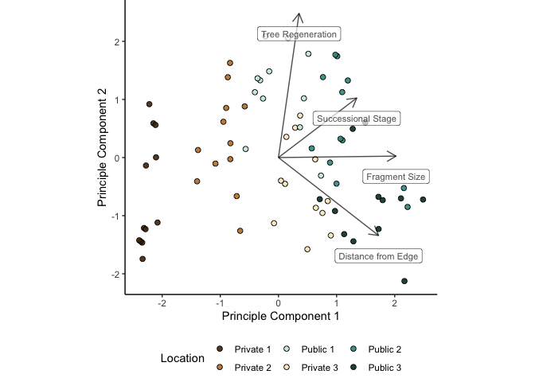

```r
levels(U$descriptors) <- c("Distance from Edge", "Fragment Size", "Tree Regeneration",
                           "Successional Stage")


biplot1 <- ggplot(F.1, aes(x = PC1, y =PC2)) +
  geom_point(aes(shape = Category, fill = Location),col = "black", size = 2, pch=21, alpha = 0.9) +
  theme_classic() +
  coord_fixed() +
  labs(x = 'Principle Component 1', y = "Principle Component 2") +
  scale_fill_manual(values = mypalette) +
  geom_segment(data = U, aes(xend = PC1*3, yend = PC2*3,x = 0, y = 0), col = "black", alpha = 0.7, arrow = arrow(length = unit(0.35, "cm"))) +
  geom_label_repel(data = U, aes(x = PC1*3, y = PC2*3, label = descriptors),
                   col = "black", nudge_y = -0.35,
                   segment.colour = NA, size = 3, alpha = 0.7) +
  theme(legend.position="bottom", legend.box = "horizontal", plot.margin=grid::unit(c(0,0,0,0), "mm"))
biplot1
```

```r
#ggsave('fig.biplotBrBu.jpeg',biplot1, units = 'cm', width = 14, height =12)
```

# 2 Modelling

## 2.1 Read in Shrub Data

```r
shrubs.f <- read.csv("data/shrubs_final.csv") %>% select(-"X")
shrubs.EI <- full_join(shrubs.f, EI7, by = c("Location", "Category", "ID"))
shrubs.EI$Category <- as.factor(shrubs.EI$Category)
names(shrubs.EI) <- sub(" ", ".", names(shrubs.EI)) #Replace spaces with .
str(shrubs.EI)
```

```
## 'data.frame':    72 obs. of  15 variables:
##  $ Location            : chr  "Code Farm" "Code Farm" "Code Farm" "Code Farm" ...
##  $ Category            : Factor w/ 3 levels "EAB Gap","Non-Gap",..: 1 1 1 1 2 2 2 2 3 3 ...
##  $ ID                  : int  1 2 3 4 1 2 3 4 1 2 ...
##  $ richness            : int  2 3 2 3 3 2 3 2 3 1 ...
##  $ H                   : num  0.5 0.965 0.693 1.099 0.736 ...
##  $ percentNN           : num  0 0 0 0 12.5 ...
##  $ percentB            : num  0 0 0 0 12.5 ...
##  $ Buckthorn           : int  0 0 0 0 10 0 0 0 10 0 ...
##  $ Edge.Distance       : num  5.59 61.89 59.79 14.57 85.46 ...
##  $ Fragment.Size       : int  37 37 37 37 37 37 37 37 37 37 ...
##  $ Percent.Tree        : int  50 90 80 30 70 50 110 100 60 40 ...
##  $ Management          : chr  "Private" "Private" "Private" "Private" ...
##  $ Buckthorn_Management: int  0 0 0 0 0 0 0 0 0 0 ...
##  $ Shade.Tolerance.Site: num  4.42 4.42 4.42 4.42 4.42 ...
##  $ Gap.Area.Site       : num  136 136 136 136 136 ...
```

### 2.1.1 Add values from PCA

```r
shrubs.EI$PC1 <- PC1
shrubs.EI$PC2 <- PC2
```

### 2.1.2 Standardize EI

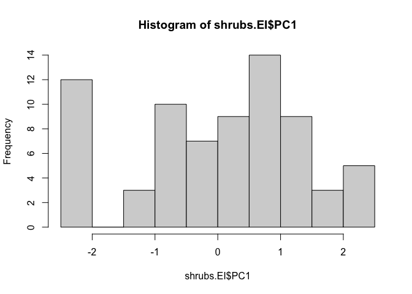

```r
hist(shrubs.EI$PC1)
```

```r
shrubs.EI %>% summarize(mean = mean(PC1) %>% round(1), sd = sd(PC1) %>% round(1)) #mean already was 0 (centered)
```

```
##   mean  sd
## 1    0 1.3
```

```r
shrubs.EI$PC1.s <- scale(shrubs.EI$PC1, center = TRUE, scale = TRUE)  #standardize
shrubs.EI %>% summarize(mean = mean(PC1.s) %>% round(1), sd = sd(PC1.s))
```

```
##   mean sd
## 1    0  1
```

```r
head(shrubs.EI)
```

```
##    Location Category ID richness         H percentNN percentB Buckthorn
## 1 Code Farm  EAB Gap  1        2 0.5004024       0.0      0.0         0
## 2 Code Farm  EAB Gap  2        3 0.9649629       0.0      0.0         0
## 3 Code Farm  EAB Gap  3        2 0.6931472       0.0      0.0         0
## 4 Code Farm  EAB Gap  4        3 1.0986123       0.0      0.0         0
## 5 Code Farm  Non-Gap  1        3 0.7356219      12.5     12.5        10
## 6 Code Farm  Non-Gap  2        2 0.5004024       0.0      0.0         0
##   Edge.Distance Fragment.Size Percent.Tree Management Buckthorn_Management
## 1          5.59            37           50    Private                    0
## 2         61.89            37           90    Private                    0
## 3         59.79            37           80    Private                    0
## 4         14.57            37           30    Private                    0
## 5         85.46            37           70    Private                    0
## 6         54.86            37           50    Private                    0
##   Shade.Tolerance.Site Gap.Area.Site        PC1         PC2      PC1.s
## 1             4.418994      136.4042 -1.3830871  0.12935587 -1.0255878
## 2             4.418994      136.4042 -0.8279143 -0.02767019 -0.6139157
## 3             4.418994      136.4042 -0.8262459  0.24628193 -0.6126785
## 4             4.418994      136.4042 -0.8987823  0.85326388 -0.6664657
## 5             4.418994      136.4042 -1.0833052 -0.10406499 -0.8032933
## 6             4.418994      136.4042 -0.7175934 -0.66407255 -0.5321104
```